# MusicTheory1

### A *very* brief introduction to music notation and (applied) music theory I for computational musicologists

author: Sebastian Klassmann (sklassm1@uni-koeln.de)  
version: 0.4  
April $13^{th}$, 2020

This introductory notebook is aimed at students interested in computational musicology. It's aim is to convey a basic understanding of fundamental concepts from music theory that can serve as a basis for using music21 productively.

The full music 21 documentation can be found [here](https://web.mit.edu/music21/doc/).

Where applicable, external sources for additional references are given as hyperlinks. Should you be interested in finding out more about a given subject, feel free to follow these links.

For displaying notation, we will be using music21 in this notebook. There will be exercises for you at select points in this notebook. For the exercises in this book, please calculate intervals and inversions yourself (i.e., don't use music21.transpose() or comparable functions).

```python
# Import cell
from music21 import *

# neccessary correction of env variables:
environment.keys()
environment.set('musicxmlPath', value='/usr/bin/musescore-xvfb')
environment.set('musescoreDirectPNGPath', value='/usr/bin/musescore-xvfb')
```

The following cell and its class will be used to be able to simplify chord entry using TinyNotation at the end of this notebook. For reference, see [music 21 documentation](http://web.mit.edu/music21/doc/usersGuide/usersGuide_16_tinyNotation.html).

```python
tnc = tinyNotation.Converter('6/8 e4. d8 c# d e2.')
tnc.parse()
s = tnc.stream
class ChordState(tinyNotation.State):
    def affectTokenAfterParse(self, n):
       super(ChordState, self).affectTokenAfterParse(n)
       return None # do not append Note object
    def end(self):
        ch = chord.Chord(self.affectedTokens)
        ch.duration = self.affectedTokens[0].duration
        return ch
tnc.bracketStateMapping['chord'] = ChordState
```

## 1. Music Notation

[figure not shown]

Music is usually notated on music *staffs*. The position of a note within the system indicates it's unique note name, while the appearance of the given note is used to denote the [rhythmic value](https://musicdiscipline.com/lead-guitar/rhythm-pyramid/) (relative duration) assigned to a given note. Notes are named after the first 7 letters of the alphabet. As you can see on the stylized piano keyboard above, notes can be altered by means of using accidentals. If we take one note and alter it one *semitone* to the right (from a white key to it's neighbouring black key, if there is one), we add a 'sharp' (#) to its note name. If we lower a note by the same amount, we add a 'flat' (b).

Two notes that in the above representation fall on the same piano key, yet are arrived at by altering different original notes, are sometimes referred to as **enharmonically identical**. This way of thinking is only possible while within the framework of [equal temperament](https://www.britannica.com/art/equal-temperament).

The distance from a given note to the next note in either direction on the keyboard that shares its name as a letter is referred to as an **octave**. The octave is the first type of musical interval that you will need to remember. It spans the distance of 12 semi-tones and it's [frequency ratio](http://legacy.earlham.edu/~tobeyfo/musictheory/Book1/FFH1_CH1/1M_RatiosCommas1.html) is 1/2.

For all of you music21 lovers out there, please note this easier way of entering notes using a function called *[tinyNotation](http://web.mit.edu/music21/doc/moduleReference/moduleTinyNotation.html)*.

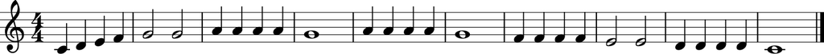

```python
s = converter.parse("tinyNotation: 4/4 c4 d4 e4 f4 g2 g2 a4 a4 a4 a4 g1 a4 a4 a4 a4 g1 f4 f4 f4 f4 e2 e2 d4 d4 d4 d4 c1")
s.show()
```

First, let us add the note names and rhythmic values to the above stream:

```python
for a in range(len(s)):
    for i in s[a].getElementsByClass(note.Note):
        i.addLyric(i.nameWithOctave)
        i.addLyric(i.duration.type)
        i.addLyric(i.offset)
```

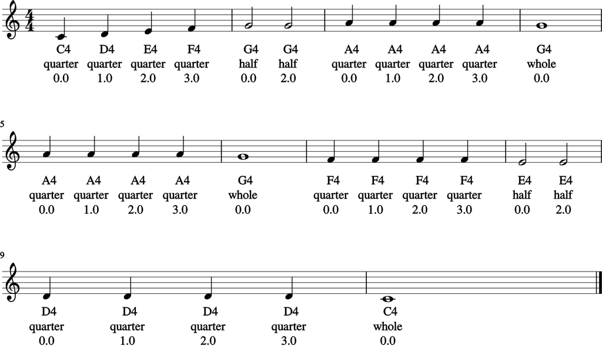

```python
s.show()
```

In addition to what has been said above, the time domain of written music is usually sliced into measures that are divided by **bar lines**. Furthermore, every piece is usually rhythmically specified by means of a **time signature**. The piece above is written in 4/4, which refers to the fact that every measure is to contain the rhythmic equivalent of the sum of four (enumerator) quarter notes (denominator).

Please note the offset values of the notes above that demonstrate rhyhtmic values in music21. These floats are relative to the measure objects that the given note is stored in.

### Exercises:

$\rightarrow$ Being able to read and write music notation will take a little while. It is merely a matter of practice. Did you catch the nested for loops that are used to add annotations (as lyrics) to the little piece above? In your own words, can you please add comments to the code to explain the inherent loop structure?

## 2. Musical Intervals

Musical intervals are relevant to both harmonic and melodic description of musical phenomena. (naive / practical definition: melody being the successive sounding of musical pitches rather than their simultaneous performance)

A definition of melodic intervals that is sufficient to the enterprise of this notebook is: musical intervals are a measure of melodic distance between distinct note events. They are categorized based on the distance between two notes, which is in turn measured in semitones. As remains to be shown below, they also form the basis for classifying chordal (or: harmonic) structures in music.

When calculating pitch classes for a given interval, keep in mind that **there is no black keys between B/C and E/F on the piano**, i.e. that when altering the pitch class "B" with a single sharp accidental, the resulting note will be enharmonically identical to a simple "C".

The following table lists melodic intervals within the span of one octave (12 semitones) with their associated distance in semitones:

| number of semitones | corresponding melodic interval(s) | example |
| --- | --- | --- |
| 1 | minor second | C - Db |
| 2 | major second | C - D |
| 3 | minor third | C - Eb |
| 4 | major third | C - E |
| 5 | perfect fourth | C - F |
| 6 | augmented fourth, tritone, diminished fifth | C - F#, C - Gb |
| 7 | perfect fifth | C - G |
| 8 | minor sixth | C - Ab |
| 9 | major sixth | C - A |
| 10 | minor seventh | C - Bb |
| 11 | major seventh | C - B |
| 12 | octave | C - C |

In general, it is advisable that you learn the interval labels and their corresponding number of semitones by heart. Let us look at these intervals in actual music notation.

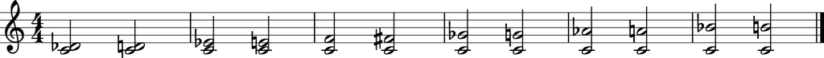

```python
s2 = converter.parse('tinyNotation: chord{c2 d-} chord{c2 d} chord{c2 e-} chord{c2 e} chord{c2 f} chord{c2 f#} chord{c2 g-} chord{c2 g} chord{c2 a-} chord{c2 a} chord{c2 b-} chord{c2 b}')
s2.show()
```

Let us create a list of intervals and add them to the above notation:

```python
intlist = ["min 2nd", "maj 2nd", "min 3rd", "maj 3rd", "perf 4th", "aug 4th", "dim 5th", "perf 5th", "min 6th", "maj 6th", "min 7th", "maj7th"]
```

Let us add the interval labels using a similar loop structure as above:

```python
ct = 0
for a in range(len(s2)):
    for i in s2[a].getElementsByClass(chord.Chord):
        i.addLyric(intlist[ct])
        ct += 1
```

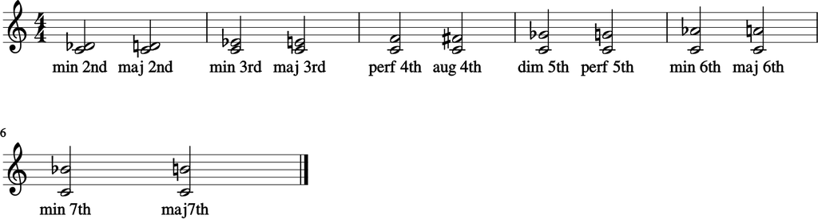

```python
s2.show()
```

### Exercises:

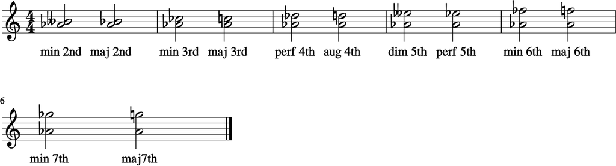

```python
s4 = converter.parse("tinyNotation: chord{a-2 b--} chord{a- b-} chord{a- c'-} chord{a- c'} chord{a- d'-} chord{a- d'} chord{a- e'--} chord{a- e'-} chord{a- f'-} chord{a- f'} chord{a- g'-} chord{a- g'}")
ct = 0
for a in range(len(s4)):
    for i in s4[a].getElementsByClass(chord.Chord):
        i.addLyric(intlist[ct])
        ct += 1
s4.show()
```

Intervals are in themselves not a difficult concept to grasp. However, it is quite beneficial to be able to calculate them without using helper software. You can pretty much come up with your own exercises. A good first exercise is the following:

$\rightarrow$ Please write out (either on a sheet of music paper or using music21) all of the above intervals (upwards) from the following starting notes:

- A
- D
- G
- F
- Bb
- Eb

For now, don't worry about enharmonically correct spelling of your resulting pitch classes. (e.g., starting from C# and calculating a major third upwards, F would be as correct as E#, even though the latter would usually be considered the right answer)

$\rightarrow$ Here are a few intervals for you to consider. Can you find out which intervals we are looking at, calculating them from the lower note upwards?

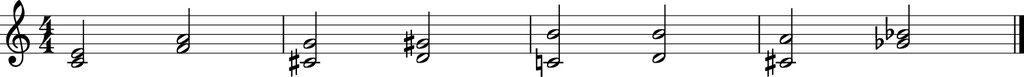

```python
intex = converter.parse('tinyNotation: chord{c2 e} chord{f2 a} chord{c#2 g} chord{d2 g#} chord{c2 b} chord{d2 b} chord{c# a} chord{g-2 b-}')
intex.show()
```

## 3. Chords / Harmonies

Going up a level in size, the next relevant buiöding block to describing tonal music are chords. For our purposes, a *chord* can be defined as a structure consisting of three or four distinct, simultaneously sounded notes. Therefore, so far, notes (pitch classes) are our most basic element. They make up intervals, which can in turn be combined into chords.

The most basic form of chord we will be encountering consists of three different pitch classes and is referred to as a triad:

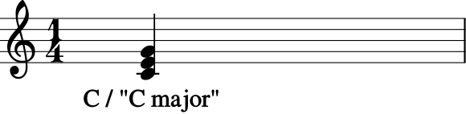

```python
C = chord.Chord(['C4', 'E4', 'G4'])
C.addLyric('C / "C major"')
C.show()
```

The above example already shows you a way that chords are usually labelled. In music, chords are generally categorized based on their interval structure. Triads in their most basic appearance are merely two thirds stacked on top of a given *root* note. Depending on which kinds of triads are stacked, the respective chords are categorized as follows:

[output not shown]

Let us look at these examples in regular music notation:

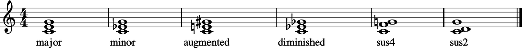

```python
chords = converter.parse('tinyNotation: chord{c1 e g}, chord{c1 e- g}, chord{c1 e g#}, chord{c1 e- g-}, chord{c1 f g}, chord{c1 d g}')
chordtypes = ["major", "minor", "augmented", "diminished", "sus4", "sus2"]

for a in range(len(chords)):
    for i in chords[a].getElementsByClass(chord.Chord):
        i.addLyric(chordtypes[a])
chords.show()
```

This time, we can use .transpose to check out these chords in a few other keys:

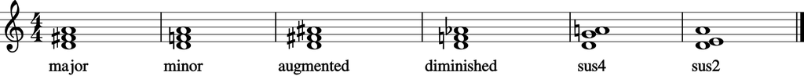

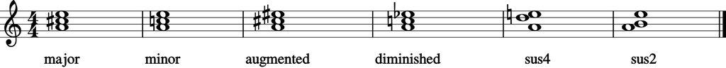

```python
chordsD = chords.transpose('M2')
chordsA = chords.transpose('M6')
chordsD.show()
chordsA.show()
```

### Exercise:

$\rightarrow$ Using music21, please print construct all six possible triads for the roots:

- D
- Eb
- E

## 4. Scales

Another building block of tonal music is usually referred to as *scales*. In music, scales can be considered both as a harmonic reservoire, as well as a melodic constituent.

There is literature (e.g., Haunschild 1994) suggesting that scales are the fundamental entity that harmony, melody, as well as composition and improvisation draw upon.

Be that as it may - the (to us) most common scale - is called a *major scale*. It consists of a collection of seven different pitch classes that constitute its tonal material. Spelled out in an ascending melody and repeating the root note an octave above, it looks as follows:

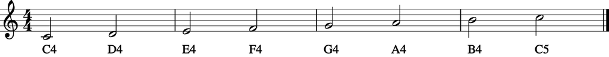

```python
cscale = converter.parse("tinyNotation: c2, d2, e2, f2, g2, a2, b2, c'2 ")

for a in range(len(cscale)):
    for i in cscale[a].getElementsByClass(note.Note):
        i.addLyric(i.nameWithOctave)
cscale.show()
```

- a certain scale is categorized by the succession of semitones and whole tones it contains.
- a major scale is composed as follows: root - whole - whole - half - whole - whole - whole - half (the last interval being the distance to the repetition of the first (root) note an octave above.
- If you stack thirds on every single note of a given scale and do not add any accidentals that the scale did not have before, you get chords that are very closely related to the scale at hand:

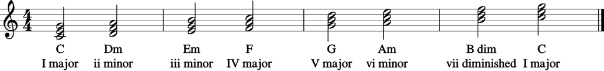

```python
csc = converter.parse("tinyNotation: chord{c2 e g}, chord{d2 f a}, chord{e2 g b}, chord{f2 a c'}, chord{g2 b d'}, chord{a2 c' e'}, chord{b2 d' f'}, chord{c'2 e' g'}")

cclasses1 = ["C", "Dm", "Em", "F", "G", "Am", "B dim", "C"]
cclasses2 = ["I major", "ii minor", "iii minor", "IV major", "V major", "vi minor", "vii diminished", "I major"]
ct = 0
for a in range(len(csc)):
    for i in csc[a].getElementsByClass(chord.Chord):
        i.addLyric(cclasses1[ct])
        i.addLyric(cclasses2[ct])
        ct += 1

csc.show()
```

This last bit of information is very relevant for musical analysis, as it introduces the notion of labelling chords by mean of roman numerals. We will get back to this a little later this semester.

As you have seen, this means that **scales are not just a succession of notes**. From this perspective, they also seem to imply certain chords that befit them.

Please remember that a major scale is defined as eight successive notes (seven distinct pitch classes) and that the semitone steps are always located between the third/fourth and seventh note/octave of a given scale. If that does not align with the chosen root, we will have to use accidentals. For example, when constructing a G major scale, without accidentals, the second semitone would be found between the sixth and seventh step of the scale (E-F). Therefore, we have to add an accidental to the seventh note in order to make the scale construction work. The resulting pitch classes for G major would be:

G - A - B - C - D - E - **F#** - G

### Exercises:

Please specify the pitch classes (notes) that construct the following major scales:

- D major
- Bb major
- Ab major

Bonus exercise:

- C# major

## Recommended Reading

- Haunschild, Frank (1994): Die neue Harmonielehre. Ein musikalisches Arbeitsbuch für Klassik, Rock, Pop und Jazz, Brühl.
- Sikora, Frank (2003): Neue Jazz-Harmonielehre. Verstehen - Hören - Spielen. Von der Theorie zur Improvisation, Mainz.